# Data Wrangling with R

# Datasets

## World Happiness Report 2018 Dataset

| Column Name | Explaination |
| --- | --- |
| Rank | Overall happiness ranking |
| Country | Country name |
| Score | Happiness score |
| GDP_Per_Capita | Economic contribution to happiness score |
| Social_Support | Social contribution to happiness score |
| Healthy_Life_Expectancy | Health contribution to happiness score |
| Freedom_To_Make_Life_Choices | Freedom contribution to happiness score |
| Generosity | Generosity contribution to happiness score |
| Perceptions_Of_Corruption | Trustworthiness contribution to happiness score |
| Residual | Portion of happiness score that is not attributed to any of the listed categories |

`vec.len` indicates how many ‘first few’ elements are displayed of each vector. You can leave it to the default value. I have set this argument to 1 for better output file formating.

```r
happy.df <- read.csv("../data/WorldHappiness2018_Data.csv")
str(happy.df, vec.len=1)
```

```
## 'data.frame':    156 obs. of  10 variables:
##  $ Rank                        : int  1 2 ...
##  $ Country                     : Factor w/ 156 levels "Afghanistan",..: 45 106 ...
##  $ Score                       : num  7.63 ...
##  $ GDP_Per_Capita              : num  1.3 ...
##  $ Social_Support              : num  1.59 ...
##  $ Healthy_Life_Expectancy     : num  0.874 0.861 ...
##  $ Freedom_To_Make_Life_Choices: num  0.681 0.686 ...
##  $ Generosity                  : num  0.192 0.286 ...
##  $ Perceptions_Of_Corruption   : Factor w/ 111 levels "0.000","0.001",..: 107 103 ...
##  $ Residual                    : Factor w/ 145 levels "0.383","0.675",..: 141 131 ...
```

Reference:

1. https://www.kaggle.com/PromptCloudHQ/world-happiness-report-2019
2. https://worldhappiness.report/ed/2019/

## Wages and Education of Young Males Datasets

| Column Name | Explaination |
| --- | --- |
| nr | Identifier |
| year | Year |
| school | Years of schooling |
| exper | Years of experience ($=$age$-6-$school) |
| union | If wage is set by collective bargaining |
| ethn | Ethnicity |
| maried | If married |
| health | If he has health problems |
| wage | Log hourly wage |
| industry | Industry that he was in |
| occupation | Occupation |
| residence | Residence location |

```r
str(Males, vec.len=1)
```

```
## 'data.frame':    4360 obs. of  12 variables:
##  $ nr        : int  13 13 ...
##  $ year      : int  1980 1981 ...
##  $ school    : int  14 14 ...
##  $ exper     : int  1 2 ...
##  $ union     : Factor w/ 2 levels "no","yes": 1 2 ...
##  $ ethn      : Factor w/ 3 levels "other","black",..: 1 1 ...
##  $ maried    : Factor w/ 2 levels "no","yes": 1 1 ...
##  $ health    : Factor w/ 2 levels "no","yes": 1 1 ...
##  $ wage      : num  1.2 ...
##  $ industry  : Factor w/ 12 levels "Agricultural",..: 7 8 ...
##  $ occupation: Factor w/ 9 levels "Professional, Technical_and_kindred",..: 9 9 ...
##  $ residence : Factor w/ 4 levels "rural_area","north_east",..: 2 2 ...
```

## NYC Flights Data in 2013

A data frame contains all 336,776 flights departing from New York City in 2013.

| Column Name | Explaination |
| --- | --- |
| year, month, day | Date of departure |
| dep_time, arr_time | Actual departure and arrival times (format HHMM or HMM), local tz. |
| sched_dep_time, sched_arr_time | Scheduled departure and arrival times (format HHMM or HMM), local tz. |
| dep_delay,arr_delay | Departure and arrival delays, in minutes. Negative times represent early departures/arrivals. |
| hour, minute | Time of scheduled departure broken into hour and minutes. |
| carrier | Two letter carrier abbreviation. See airlines() to get name |
| tailnum | Plane tail number |
| flight | Flight number |
| origin, dest | Origin and destination. See airports() for additional metadata. |
| air_time | Amount of time spent in the air, in minutes |
| distance | Distance between airports, in miles |
| time_hour | Scheduled date and hour of the flight as a POSIXct date. Along with origin, can be used to join flights data to weather data. |

```r
str(flights)
```

```
## Classes 'tbl_df', 'tbl' and 'data.frame':    336776 obs. of  19 variables:
##  $ year          : int  2013 2013 2013 2013 2013 2013 2013 2013 2013 2013 ...
##  $ month         : int  1 1 1 1 1 1 1 1 1 1 ...
##  $ day           : int  1 1 1 1 1 1 1 1 1 1 ...
##  $ dep_time      : int  517 533 542 544 554 554 555 557 557 558 ...
##  $ sched_dep_time: int  515 529 540 545 600 558 600 600 600 600 ...
##  $ dep_delay     : num  2 4 2 -1 -6 -4 -5 -3 -3 -2 ...
##  $ arr_time      : int  830 850 923 1004 812 740 913 709 838 753 ...
##  $ sched_arr_time: int  819 830 850 1022 837 728 854 723 846 745 ...
##  $ arr_delay     : num  11 20 33 -18 -25 12 19 -14 -8 8 ...
##  $ carrier       : chr  "UA" "UA" "AA" "B6" ...
##  $ flight        : int  1545 1714 1141 725 461 1696 507 5708 79 301 ...
##  $ tailnum       : chr  "N14228" "N24211" "N619AA" "N804JB" ...
##  $ origin        : chr  "EWR" "LGA" "JFK" "JFK" ...
##  $ dest          : chr  "IAH" "IAH" "MIA" "BQN" ...
##  $ air_time      : num  227 227 160 183 116 150 158 53 140 138 ...
##  $ distance      : num  1400 1416 1089 1576 762 ...
##  $ hour          : num  5 5 5 5 6 5 6 6 6 6 ...
##  $ minute        : num  15 29 40 45 0 58 0 0 0 0 ...
##  $ time_hour     : POSIXct, format: "2013-01-01 05:00:00" "2013-01-01 05:00:00" ...
```

# dplyr: Data Transformation

## filter()

> `filter()` allows you to subset rows based on criterions related to their values

Operations that can be used to set up criterions include:

1. comparisons: `>`, `>=`, `<`, `<=`, `==` (equal), `!=` (not equal)
2. logical operators: `&` (and), `|` (or). Don’t use `&&` or `||`.
3. `%in%` operator.

`dplyr` functions can be used both with and without pipe (`%>%`). When used without pipe, the first argument to the function is the dataframe. For example, to subset all observations recorded in the year 1980:

```r
filter(Males, year == 1980)
```

```
## # A tibble: 545 x 12
##       nr  year school exper union ethn  maried health  wage industry
##    <int> <int>  <int> <int> <fct> <fct> <fct>  <fct>  <dbl> <fct>
##  1    13  1980     14     1 no    other no     no     1.20  Busines…
##  2    17  1980     13     4 no    other no     no     1.68  Trade
##  3    18  1980     12     4 no    other yes    no     1.52  Trade
##  4    45  1980     12     2 yes   other no     no     1.89  Transpo…
##  5   110  1980     12     5 yes   other no     no     1.95  Profess…
##  6   120  1980     10     2 no    other no     no     0.259 Trade
##  7   126  1980     13     2 no    other no     no     1.74  Trade
##  8   150  1980     12     2 no    other no     no     1.21  Busines…
##  9   162  1980     11     2 yes   other no     no     0.502 Trade
## 10   166  1980     10     2 yes   other no     no     1.01  Trade
## # ... with 535 more rows, and 2 more variables: occupation <fct>,
## #   residence <fct>
```

However, you are encouraged to call dplyr functions with pipe, because it outlines the sequences of how a dataframe is processed, therefore, more clear logically.

Simply put, the following two expressions are identical:

```r
# expression 1
x %>%
  function(y)

# expression 2
function(x, y)
```

> Pipe symbol `%>%` takes whatever returns from the previous step as the first argument of the subsequent function.

In the context of applying dplyr functions, the following formula comes in handy.

```r
> data.frame %>%
>   function1(arguments) %>%
>   function2(arguments) %>%
> ...
```

For example, to subset observations in the year 1980 with pipe:

```r
Males %>%
  filter(year == 1980)
```

```
## # A tibble: 545 x 12
##       nr  year school exper union ethn  maried health  wage industry
##    <int> <int>  <int> <int> <fct> <fct> <fct>  <fct>  <dbl> <fct>
##  1    13  1980     14     1 no    other no     no     1.20  Busines…
##  2    17  1980     13     4 no    other no     no     1.68  Trade
##  3    18  1980     12     4 no    other yes    no     1.52  Trade
##  4    45  1980     12     2 yes   other no     no     1.89  Transpo…
##  5   110  1980     12     5 yes   other no     no     1.95  Profess…
##  6   120  1980     10     2 no    other no     no     0.259 Trade
##  7   126  1980     13     2 no    other no     no     1.74  Trade
##  8   150  1980     12     2 no    other no     no     1.21  Busines…
##  9   162  1980     11     2 yes   other no     no     0.502 Trade
## 10   166  1980     10     2 yes   other no     no     1.01  Trade
## # ... with 535 more rows, and 2 more variables: occupation <fct>,
## #   residence <fct>
```

`filter()` accepts multiple conditions seperated by commas.

> Multiple conditions are treated as and (`&`) logically.

To subset hispanic observations in the year 1980:

```r
Males %>%
  filter(year == 1980, ethn == "hisp")
```

```
## # A tibble: 85 x 12
##       nr  year school exper union ethn  maried health  wage industry
##    <int> <int>  <int> <int> <fct> <fct> <fct>  <fct>  <dbl> <fct>
##  1  1142  1980     14     2 no    hisp  no     no     1.41  Trade
##  2  1641  1980     12     4 no    hisp  no     no     2.11  Trade
##  3  1644  1980     12     1 yes   hisp  no     no     0.561 Enterta…
##  4  1721  1980     11     5 no    hisp  no     no     1.78  Trade
##  5  1763  1980     11     1 no    hisp  no     no     0.644 Persona…
##  6  2386  1980     10     2 yes   hisp  no     no     1.20  Finance
##  7  2874  1980      9     4 no    hisp  no     no     0.379 Trade
##  8  3282  1980     10     3 no    hisp  no     no     1.36  Constru…
##  9  4264  1980     10     4 no    hisp  yes    no     1.23  Manufac…
## 10  4321  1980     11     1 no    hisp  no     no     1.72  Trade
## # ... with 75 more rows, and 2 more variables: occupation <fct>,
## #   residence <fct>
```

> Other logical relationships should be explicitly specified.

For example:

```r
Males %>%
  filter(year == 1980 | maried == "no")
```

```
## # A tibble: 2,547 x 12
##       nr  year school exper union ethn  maried health   wage industry
##    <int> <int>  <int> <int> <fct> <fct> <fct>  <fct>   <dbl> <fct>
##  1    13  1980     14     1 no    other no     no      1.20  Busines…
##  2    13  1981     14     2 yes   other no     no      1.85  Persona…
##  3    13  1982     14     3 no    other no     no      1.34  Busines…
##  4    13  1983     14     4 no    other no     no      1.43  Busines…
##  5    13  1984     14     5 no    other no     no      1.57  Persona…
##  6    13  1985     14     6 no    other no     no      1.70  Busines…
##  7    13  1986     14     7 no    other no     no     -0.720 Busines…
##  8    13  1987     14     8 no    other no     no      1.67  Busines…
##  9    17  1980     13     4 no    other no     no      1.68  Trade
## 10    17  1981     13     5 no    other no     no      1.52  Trade
## # ... with 2,537 more rows, and 2 more variables: occupation <fct>,
## #   residence <fct>
```

Finally, let’s look at an example of `%in%`. `%in%` is equivalent to “is an instance of” in statistics. For example, if $x$ is an instance of the set $X$, then `x %in% X` will return `TRUE`.

To subset observations from year 1980 to 1983 (both inclusive):

```r
Males %>%
  filter(year %in% 1980:1983)
```

```
## # A tibble: 2,180 x 12
##       nr  year school exper union ethn  maried health  wage industry
##    <int> <int>  <int> <int> <fct> <fct> <fct>  <fct>  <dbl> <fct>
##  1    13  1980     14     1 no    other no     no      1.20 Busines…
##  2    13  1981     14     2 yes   other no     no      1.85 Persona…
##  3    13  1982     14     3 no    other no     no      1.34 Busines…
##  4    13  1983     14     4 no    other no     no      1.43 Busines…
##  5    17  1980     13     4 no    other no     no      1.68 Trade
##  6    17  1981     13     5 no    other no     no      1.52 Trade
##  7    17  1982     13     6 no    other no     no      1.56 Trade
##  8    17  1983     13     7 no    other no     no      1.73 Trade
##  9    18  1980     12     4 no    other yes    no      1.52 Trade
## 10    18  1981     12     5 no    other yes    no      1.74 Trade
## # ... with 2,170 more rows, and 2 more variables: occupation <fct>,
## #   residence <fct>
```

> `filter()` excludes `NA` for you

```r
data.frame(x = c(1, NA, NA, 4)) %>%
  filter(x > 1)
```

```
##   x
## 1 4
```

## arrange()

> `arrange()` changes the order of rows. Usually, it is used to sort observations in ascending (by default) or descending order (with `desc()`).

The argument to `arrange()` is simply the column names. By default, the observations will be organized in ascending order. If multiple columns are passed, latter columns will only have effect for those observations that share the value of ALL preceding columns.

For example, observations are first sorted by `year` in ascending order, so observations in the year 1980 come to the front. For observations occur in the same year, their order is further determined by the value in the column `school`:

```r
Males %>%
  arrange(year, school)
```

```
## # A tibble: 4,360 x 12
##       nr  year school exper union ethn  maried health  wage industry
##    <int> <int>  <int> <int> <fct> <fct> <fct>  <fct>  <dbl> <fct>
##  1  8107  1980      3    11 no    hisp  no     no      1.11 Manufac…
##  2  6463  1980      5     7 no    other no     no      1.23 Constru…
##  3  9131  1980      5     9 no    other no     no      1.11 Constru…
##  4  4261  1980      6     9 no    other yes    no      1.85 Constru…
##  5  7238  1980      6     8 yes   hisp  no     no      1.34 Trade
##  6  8096  1980      6    11 yes   hisp  no     no      1.69 Trade
##  7  9132  1980      6     7 no    other yes    no      1.22 Constru…
##  8 11890  1980      6    10 no    hisp  yes    no      1.27 Trade
##  9  3271  1980      7     6 yes   other no     no      1.64 Constru…
## 10  4000  1980      7     9 no    other no     no      1.61 Constru…
## # ... with 4,350 more rows, and 2 more variables: occupation <fct>,
## #   residence <fct>
```

To sort observations in descending order, pass the column to function `desc()` first.

```r
happy.df %>%
  arrange(desc(Rank))
```

```
## # A tibble: 156 x 10
##     Rank Country Score GDP_Per_Capita Social_Support Healthy_Life_Ex…
##    <int> <fct>   <dbl>          <dbl>          <dbl>            <dbl>
##  1   156 Burundi  2.90          0.091          0.627            0.145
##  2   155 Centra…  3.08          0.024          0                0.01
##  3   154 South …  3.25          0.337          0.608            0.177
##  4   153 Tanzan…  3.30          0.455          0.991            0.381
##  5   152 Yemen    3.36          0.442          1.07             0.343
##  6   151 Rwanda   3.41          0.332          0.896            0.4
##  7   150 Syria    3.46          0.689          0.382            0.539
##  8   149 Liberia  3.50          0.076          0.858            0.267
##  9   148 Haiti    3.58          0.315          0.714            0.289
## 10   147 Malawi   3.59          0.186          0.541            0.306
## # ... with 146 more rows, and 4 more variables:
## #   Freedom_To_Make_Life_Choices <dbl>, Generosity <dbl>,
## #   Perceptions_Of_Corruption <fct>, Residual <fct>
```

> Missing values are always sorted at the end, regardless of ascending or descending order.

```r
df <- tibble(x = c(15, NA, 22, NA, -43, NA))
df %>%
  arrange(x)
```

```
## # A tibble: 6 x 1
##       x
##   <dbl>
## 1   -43
## 2    15
## 3    22
## 4    NA
## 5    NA
## 6    NA
```

```r
df %>%
  arrange(desc(x))
```

```
## # A tibble: 6 x 1
##       x
##   <dbl>
## 1    22
## 2    15
## 3   -43
## 4    NA
## 5    NA
## 6    NA
```

How to sort all missing values to the start?

```r
df %>%
  arrange(desc(is.na(x)), x)
```

```
## # A tibble: 6 x 1
##       x
##   <dbl>
## 1    NA
## 2    NA
## 3    NA
## 4   -43
## 5    15
## 6    22
```

## select()

It is not uncommon for the number of columns to reach hundreds or even thousands level. Under this circumstances, it is helpful to single out a few more important columns and examine them first.

> `select()` is use to subset columns from a dataframe.

`select()` is similar to `filter()` for rows.

The dataframe `Males` contain 12 columns. Suppose we are only concerned with 4 of them: `school`, `maried`, `health` and `wage`. To create a sub-dataframe with only those four columns:

```r
Males %>%
  select(school, maried, health, wage)
```

```
## # A tibble: 4,360 x 4
##    school maried health   wage
##  *  <int> <fct>  <fct>   <dbl>
##  1     14 no     no      1.20
##  2     14 no     no      1.85
##  3     14 no     no      1.34
##  4     14 no     no      1.43
##  5     14 no     no      1.57
##  6     14 no     no      1.70
##  7     14 no     no     -0.720
##  8     14 no     no      1.67
##  9     13 no     no      1.68
## 10     13 no     no      1.52
## # ... with 4,350 more rows
```

> You can use `:` to select all the columns continuously

Suppose we would like to select all columns between `year` and `wage`:

```r
Males %>%
  select(year:wage)
```

```
## # A tibble: 4,360 x 8
##     year school exper union ethn  maried health   wage
##  * <int>  <int> <int> <fct> <fct> <fct>  <fct>   <dbl>
##  1  1980     14     1 no    other no     no      1.20
##  2  1981     14     2 yes   other no     no      1.85
##  3  1982     14     3 no    other no     no      1.34
##  4  1983     14     4 no    other no     no      1.43
##  5  1984     14     5 no    other no     no      1.57
##  6  1985     14     6 no    other no     no      1.70
##  7  1986     14     7 no    other no     no     -0.720
##  8  1987     14     8 no    other no     no      1.67
##  9  1980     13     4 no    other no     no      1.68
## 10  1981     13     5 no    other no     no      1.52
## # ... with 4,350 more rows
```

> You can put the negative sign `-` in front of column names to exclude those columns

This works for a single columns, a vector, or a sequence specified by `:`

```r
Males %>%
  select(-c(year, union))
```

```
## # A tibble: 4,360 x 10
##       nr school exper ethn  maried health   wage industry occupation
##  * <int>  <int> <int> <fct> <fct>  <fct>   <dbl> <fct>    <fct>
##  1    13     14     1 other no     no      1.20  Busines… Service_W…
##  2    13     14     2 other no     no      1.85  Persona… Service_W…
##  3    13     14     3 other no     no      1.34  Busines… Service_W…
##  4    13     14     4 other no     no      1.43  Busines… Service_W…
##  5    13     14     5 other no     no      1.57  Persona… Craftsmen…
##  6    13     14     6 other no     no      1.70  Busines… Managers,…
##  7    13     14     7 other no     no     -0.720 Busines… Managers,…
##  8    13     14     8 other no     no      1.67  Busines… Managers,…
##  9    17     13     4 other no     no      1.68  Trade    Managers,…
## 10    17     13     5 other no     no      1.52  Trade    Managers,…
## # ... with 4,350 more rows, and 1 more variable: residence <fct>
```

### Handy helper functions that can be used in `select()`

1. `starts_with("str")`
2. `ends_with("str")`
3. `contains("str")`
4. `one_of()` #matches variable names in a character vector
5. `everything()` #matches all variables
6. `matches("(.)\\1")` #matches a regular expression
7. `num_range("x", 1:3)` #matches x1, x2 and x3
8. `last_col(offset=0)` #select last $n$ column, specified by `offset=`

```r
happy.df %>%
  select(starts_with("G"))
```

```
## # A tibble: 156 x 2
##    GDP_Per_Capita Generosity
##             <dbl>      <dbl>
##  1           1.30      0.192
##  2           1.46      0.286
##  3           1.35      0.284
##  4           1.34      0.353
##  5           1.42      0.256
##  6           1.36      0.333
##  7           1.33      0.321
##  8           1.27      0.365
##  9           1.36      0.285
## 10           1.34      0.361
## # ... with 146 more rows
```

> Special function `everything()` can be used to put the most important columns to the front.

```r
Males %>%
  select(wage, school, everything())
```

```
## # A tibble: 4,360 x 12
##      wage school    nr  year exper union ethn  maried health industry
##  *  <dbl>  <int> <int> <int> <int> <fct> <fct> <fct>  <fct>  <fct>
##  1  1.20      14    13  1980     1 no    other no     no     Busines…
##  2  1.85      14    13  1981     2 yes   other no     no     Persona…
##  3  1.34      14    13  1982     3 no    other no     no     Busines…
##  4  1.43      14    13  1983     4 no    other no     no     Busines…
##  5  1.57      14    13  1984     5 no    other no     no     Persona…
##  6  1.70      14    13  1985     6 no    other no     no     Busines…
##  7 -0.720     14    13  1986     7 no    other no     no     Busines…
##  8  1.67      14    13  1987     8 no    other no     no     Busines…
##  9  1.68      13    17  1980     4 no    other no     no     Trade
## 10  1.52      13    17  1981     5 no    other no     no     Trade
## # ... with 4,350 more rows, and 2 more variables: occupation <fct>,
## #   residence <fct>
```

In this scenario, does `everything()` include `wage`?

## rename()

> `rename()` is used to rename the name of columns. The syntax is `rename(new_name = old_name)`

For example, rename the `nr` to `id` since `nr` is the identifier of individual. `id` is a better name because it is more straightforward.

```r
Males %>%
  rename(id = nr)
```

```
## # A tibble: 4,360 x 12
##       id  year school exper union ethn  maried health   wage industry
##  * <int> <int>  <int> <int> <fct> <fct> <fct>  <fct>   <dbl> <fct>
##  1    13  1980     14     1 no    other no     no      1.20  Busines…
##  2    13  1981     14     2 yes   other no     no      1.85  Persona…
##  3    13  1982     14     3 no    other no     no      1.34  Busines…
##  4    13  1983     14     4 no    other no     no      1.43  Busines…
##  5    13  1984     14     5 no    other no     no      1.57  Persona…
##  6    13  1985     14     6 no    other no     no      1.70  Busines…
##  7    13  1986     14     7 no    other no     no     -0.720 Busines…
##  8    13  1987     14     8 no    other no     no      1.67  Busines…
##  9    17  1980     13     4 no    other no     no      1.68  Trade
## 10    17  1981     13     5 no    other no     no      1.52  Trade
## # ... with 4,350 more rows, and 2 more variables: occupation <fct>,
## #   residence <fct>
```

`select()` can be used to rename a column too. However, it is rarely used because it drops all unselected columns, which is usually not desirable.

```r
Males %>%
  select(id = nr)
```

```
## # A tibble: 4,360 x 1
##       id
##  * <int>
##  1    13
##  2    13
##  3    13
##  4    13
##  5    13
##  6    13
##  7    13
##  8    13
##  9    17
## 10    17
## # ... with 4,350 more rows
```

How can you use `select()` to obtain the exact result from `rename()`?

```r
Males %>%
  select(id = nr, everything())
```

```
## # A tibble: 4,360 x 12
##       id  year school exper union ethn  maried health   wage industry
##  * <int> <int>  <int> <int> <fct> <fct> <fct>  <fct>   <dbl> <fct>
##  1    13  1980     14     1 no    other no     no      1.20  Busines…
##  2    13  1981     14     2 yes   other no     no      1.85  Persona…
##  3    13  1982     14     3 no    other no     no      1.34  Busines…
##  4    13  1983     14     4 no    other no     no      1.43  Busines…
##  5    13  1984     14     5 no    other no     no      1.57  Persona…
##  6    13  1985     14     6 no    other no     no      1.70  Busines…
##  7    13  1986     14     7 no    other no     no     -0.720 Busines…
##  8    13  1987     14     8 no    other no     no      1.67  Busines…
##  9    17  1980     13     4 no    other no     no      1.68  Trade
## 10    17  1981     13     5 no    other no     no      1.52  Trade
## # ... with 4,350 more rows, and 2 more variables: occupation <fct>,
## #   residence <fct>
```

## mutate()

Sometimes it would be helpful to generate new features from existing columns. `mutate()` help you achieve this.

> `mutate()` generates new features from existing columns and append them to the end of the dataframe.

For example, in the `happy.df` dataset, one may be interested in the difference between two adjacent happiness score.

```r
happy.df %>%
  mutate(score.diff = Score - lag(Score)) %>%
  select(Score, score.diff)
```

```
## # A tibble: 156 x 2
##    Score score.diff
##    <dbl>      <dbl>
##  1  7.63   NA
##  2  7.59   -0.0380
##  3  7.56   -0.039
##  4  7.50   -0.0600
##  5  7.49   -0.008
##  6  7.44   -0.046
##  7  7.33   -0.113
##  8  7.32   -0.004
##  9  7.31   -0.01000
## 10  7.27   -0.0420
## # ... with 146 more rows
```

Same as all dplyr functions, all changes are not made in-place.

```r
"score.df" %in% colnames(happy.df)
```

```
## [1] FALSE
```

To preserve changes, remember to assign the returned dataframe to a new variable or even replace the original dataframe.

```r
delta.score.df <-
  happy.df %>%
  mutate(score.diff = Score - lag(Score)) %>%
  select(Score, score.diff)
```

```r
str(delta.score.df)
```

```
## Classes 'tbl_df', 'tbl' and 'data.frame':    156 obs. of  2 variables:
##  $ Score     : num  7.63 7.59 7.55 7.5 7.49 ...
##  $ score.diff: num  NA -0.038 -0.039 -0.06 -0.008 ...
```

If you ONLY want to keep the new variables, try `transmute()`

```r
happy.df %>%
  transmute(score.diff = Score - lag(Score))
```

```
## # A tibble: 156 x 1
##    score.diff
##         <dbl>
##  1   NA
##  2   -0.0380
##  3   -0.039
##  4   -0.0600
##  5   -0.008
##  6   -0.046
##  7   -0.113
##  8   -0.004
##  9   -0.01000
## 10   -0.0420
## # ... with 146 more rows
```

How to make `mutate()` produce the same results as `transmute()`?

```r
happy.df %>%
  mutate(score.diff = Score - lag(Score)) %>%
  select(score.diff)
```

```
## # A tibble: 156 x 1
##    score.diff
##         <dbl>
##  1   NA
##  2   -0.0380
##  3   -0.039
##  4   -0.0600
##  5   -0.008
##  6   -0.046
##  7   -0.113
##  8   -0.004
##  9   -0.01000
## 10   -0.0420
## # ... with 146 more rows
```

### Creation Functions

Operations that can be used in `mutate()` or `transmute()`

1. Arithmetic operators: `+` `-` `*` `/` `^`
2. Modular arithmetic: `%/%` (integer division) `%%`(remainder)
3. Logs: `log()` `log2()` `log10()`
4. Offsets: `lead()` and `lag()`
5. Cumulative and rolling aggregates: `cumsum()` `cumprod()` `cummin()` `cummax()` `cummean()`
6. Logical comparisons: `<` `<=` `>` `>=` `!=`
7. Ranking `min_rank()` `row_number()` `dense_rank()` `percent_rank()` `cume_dist()` `ntile()`

## summarize()

> `summarize()` most of the time works with `group_by()` to obtain group statistics.

```r
Males %>%
  group_by(maried, health) %>%
  summarize(mean.wage = mean(wage, na.rm=TRUE),
            count = n(),
            missing.count = sum(is.na(wage)))
```

```
## # A tibble: 4 x 5
## # Groups:   maried [?]
##   maried health mean.wage count missing.count
##   <fct>  <fct>      <dbl> <int>         <int>
## 1 no     no          1.55  2399             0
## 2 no     yes         1.50    47             0
## 3 yes    no          1.78  1887             0
## 4 yes    yes         1.57    27             0
```

Note that columns passed to `group_by()` should be categorical variables (Factor). Since both `maried` and `health` are binary (either has only 2 level - yes and no), there are in total 4 resultant groups. The statistics summarized by `summary()` is the statistics specific to each group.

### Summary Functions

1. measures of location `mean(x)` `median(x)`
2. measures of spread `sd(x)` `IQR(x)` `mad(x)`
3. measures of rank `min(x)` `quantile(x, 0.25)` `max(x)`
4. measures of position `first(x)` `nth(x, 2)` `last(x)`
5. counts `n()` `n_distinct(x)`
6. counts and proportions of logical values `sum(x > 10)` `mean(y == 0)`

> It is a good practice to pass `na.rm=TRUE` everytime one calls those summary functions, since every operation on `NA` yields `NA`, which typically jeopardizes analysis.

### Ungrouping

> `ungroup()` removes grouping

```r
Males %>%
  group_by(maried, health) %>%
  ungroup() %>%
  summarize(mean.wage = mean(wage, na.rm=TRUE),
            count = n(),
            missing.count = sum(is.na(wage)))
```

```
## # A tibble: 1 x 3
##   mean.wage count missing.count
##       <dbl> <int>         <int>
## 1      1.65  4360             0
```

## Summary

| Command Names | Tasks |
| --- | --- |
| `filter` | filtering rows by setting rules |
| `arrange` | reordering rows |
| `select` | selecting columns by names |
| `rename` | renaming column names, and return all columns |
| `mutate` | creating new variables with functions of existing columns |
| `transmute` | creating new variables with functions of existing columns and returning only the new variables |
| `group_by` | grouping factors |
| `ungroup` | removing all groups |
| `summarize` | obtaining statistical summary, such as mean, count, standard deviation, from selected data |

# readr: Data Import and Output

| Function Names | Tasks |
| --- | --- |
| `read_csv()` | read comma-delimited files |
| `read_csv2()` | read semicolon-separated files |
| `read_tsv()` | reads tab-delimited files |
| `read_delim()` | reads in files with any delimiter |
| `write_csv()` | writes comma-delimited files to disk |
| `write_tsv()` | writes tab-delimited files to disk |

> The first argument to these functions are the path to the file to read.

## Under the Default Setting

```r
happy.df2 <- read_csv("../data/WorldHappiness2018_Data.csv")
```

> By default, `read_csv()` uses the first line of data for column names.

In the occasion that this is not the case, some additional arguments should be adjusted.

## Skip First Few Rows

```r
read_csv("This example is created
          to demonstrated how to use `skip`
          x, y, z
          1, 2, 3
          4, 5, 6", skip = 2)
```

```
## # A tibble: 2 x 3
##       x     y     z
##   <int> <int> <int>
## 1     1     2     3
## 2     4     5     6
```

## Skip Comments

```r
read_csv("# This example is created
          x, y, z  #column name
          1, 2, 3
          4, 5, 6", comment = "#")
```

```
## # A tibble: 2 x 3
##       x     y     z
##   <int> <int> <int>
## 1     1     2     3
## 2     4     5     6
```

Please note that `read_csv()` does not ignore rows containing “#”. Instead, it only neglects strings come after “#”. In other words, warning will occur if there are only spaces preceeding “#”.

## No Column Names

```r
read_csv("1,2,3\n4,5,6", col_names = FALSE)
```

```
## # A tibble: 2 x 3
##      X1    X2    X3
##   <int> <int> <int>
## 1     1     2     3
## 2     4     5     6
```

If no column names are provided, R labels them sequentially from X1 to Xn. Alternatively, you can pass the column names as a vector.

```r
read_csv("1,2,3\n4,5,6", col_names = c("a", "b", "c"))
```

```
## # A tibble: 2 x 3
##       a     b     c
##   <int> <int> <int>
## 1     1     2     3
## 2     4     5     6
```

## Handle `NA` values

The missing value in R by default is spelt as `NA`. However, conventionally, null, NAN, NaN even some special symbols are used to represent missing values. To import whatever is supposed to be missing values as `NA` instead of strings, one needs to specify how the file to be imported represent missing values.

If left without handling, NaN, null will be treated as characters instead of missing values

```r
read_csv("a,b,c\n1,2,null\nNaN,5,6")
```

```
## # A tibble: 2 x 3
##       a     b c
##   <dbl> <int> <chr>
## 1     1     2 null
## 2   NaN     5 6
```

`na = "NaN"` tells R that the document uses `NaN` to represent missing values.

```r
read_csv("a,b,c\n1,2,null \nNaN,5,6", na = "NaN")
```

```
## # A tibble: 2 x 3
##       a     b c
##   <int> <int> <chr>
## 1     1     2 null
## 2    NA     5 6
```

In this example, the document uses mixed notations to represent missing values. In this case, pass all missing value representations as a vector.

```r
read_csv("a,b,c\n1,2,.\nNaN,5,6", na = c(".", "NaN"))
```

```
## # A tibble: 2 x 3
##       a     b     c
##   <int> <int> <int>
## 1     1     2    NA
## 2    NA     5     6
```

## Write to a File

```r
write_csv(df, path)
```

`df` is a dataframe and path is the location you want the file saved at.

# stringr: Strings and Regular Expressions

## String Basics

> You can create a string with either single quotes or double quotes.

```r
single.quote <- 'a single quote string'
double.quote <- "a double quote sting"
```

> To include a literal single or double quote, you can either use \ to escape it, or use single quotes and double quotes alternatively.

```r
lit.double.quote <- '"' # or "\""
lit.double.quote
```

```
## [1] "\""
```

```r
lit.single.quote <- '\'' # or "'"
lit.single.quote
```

```
## [1] "'"
```

Quiz. How to include a literal backslash `\`?

## Special Characters

There are many special characters represented by strings. The most common are `\n`, for newline, and `\t` for tab.

```r
writeLines("First line\nSecond line\tA tab")
```

```
## First line
## Second line  A tab
```

Unicode is mapping of string to special symbols. Those strings start with “\u”, followed by four-digit numbers or English letters. You can find the mapping table [here](https://unicode-table.com/en/).

```r
writeLines("\u2602")
```

```
## ☂
```

## writeLines()

`writeLines` is the R equivalence of `print` function of Python. It is used to display the raw contents of the string. For example:

```r
lit.double.quote
```

```
## [1] "\""
```

```r
writeLines(lit.double.quote)
```

```
## "
```

Without `writeLines`, `\n` and `\t` will not be interpreted.

```r
"First line\nSecond line\tA tab"
```

```
## [1] "First line\nSecond line\tA tab"
```

```r
writeLines("First line\nSecond line\tA tab")
```

```
## First line
## Second line  A tab
```

## str_length()

The functions from `stringr` all start with `str_`. Starting from this subsections, I will introduce a few most commonly used string functions from `stringr`.

> `str_length()` tells you the number of characters in a string.

```r
str_length(c("happy", "sad", "calm"))
```

```
## [1] 5 3 4
```

## str_c()

> `str_c()` combines two or more strings

```r
str_c("a", "b", "c")
```

```
## [1] "abc"
```

> Arg 1: use `sep` to control how they are separated

```r
str_c("a", "b", "c", sep = ", ")
```

```
## [1] "a, b, c"
```

```r
writeLines(str_c("a", "b", "c", sep="\n"))
```

```
## a
## b
## c
```

`str_c()` is vectorized, which means if a vector is passed to it, then `str_c()` is applied to each item in the vector.

```r
x <- c("Tom", "Jerry", "Sam", "Lucy")
str_c("Welcome to the class,", x, "!", sep = " ")
```

```
## [1] "Welcome to the class, Tom !"   "Welcome to the class, Jerry !"
## [3] "Welcome to the class, Sam !"   "Welcome to the class, Lucy !"
```

> Arg 2: To collapse a vector of strings into a single string, use `collapse`

```r
str_c(x, collapse = ", ")
```

```
## [1] "Tom, Jerry, Sam, Lucy"
```

## str_replace_na()

> `str_replace_na()` turn `NA` into “NA”

```r
x <- c("ab", "cd", NA, "gh")
str_replace_na(x)
```

```
## [1] "ab" "cd" "NA" "gh"
```

## str_sub()

> `str_sub()` extract parts of a string. The template is `str_sub(string, start, end)`

```r
x <- c("Engineering", "Medicine", "Social Science", "Law", "Business")
str_sub(x, 1, 3)
```

```
## [1] "Eng" "Med" "Soc" "Law" "Bus"
```

Similar to Python, negative numbers count backwards from the end

```r
str_sub(x, -3, -1)
```

```
## [1] "ing" "ine" "nce" "Law" "ess"
```

## str_to_lower()

> str_to_lower() changes all letters to lowercase.

```r
x <- c("Engineering", "Medicine", "Social Science", "Law", "Business")
str_to_lower(x)
```

```
## [1] "engineering"    "medicine"       "social science" "law"
## [5] "business"
```

Similarly, there is `str_to_upper()` and `str_to_title()`

```r
x <- str_to_upper(x)
x
```

```
## [1] "ENGINEERING"    "MEDICINE"       "SOCIAL SCIENCE" "LAW"
## [5] "BUSINESS"
```

```r
str_to_title("the university of hong kong")
```

```
## [1] "The University Of Hong Kong"
```

## str_view()

In large datasets, it is likely that string-type columns carry important information. However, strings usually cannot be processed directly. A typical pipeline is to use regular expressions to identify different groups of strings with common patterns and encode them accordingly. `str_view()` and `str_view_all()` allow us to match strings by regular expressions. `str_vew()` shows the first match, while `str_view_all()` shows all the matches.

### Exact Match

```r
x <- c("Engineering", "Medicine", "Science", "Social Science")
str_view(x, "ne")
```

[interactive chart not shown]

### `.` to match any character except a newline

```r
str_view(x, ".e.")
```

[interactive chart not shown]

### `^` to match the start of the string

```r
str_view(x, "^Sci")
```

[interactive chart not shown]

### `$` to match the end of the string

```r
str_view(x, "ing$")
```

[interactive chart not shown]

### `\d` to match any digit

But remember you need to escape the “\” for the string.

```r
x <- c("in the winter of 1993", "23 years old")
str_view(x, "\\d")
```

[interactive chart not shown]

### `\s` to match any spaces

```r
str_view_all(x, "\\s")
```

[interactive chart not shown]

### Alternatives

[output not shown]

### Repetition

| Expression | Meaning |
| --- | --- |
| ? | the pattern repeats 0 or 1 times |
| + | the pattern repeats 1 or more times |
| * | the pattern repeats 0 or more times |

```r
x <- c("Engineering", "Medicine", "Science", "Social Science")
str_view(x, "^S[a-zA-Z ]+ce$")
```

[interactive chart not shown]

## str_detect()

> `str_detect()` returns a logical vector the same length as the input indicating if the patter appear.

```r
x <- c("Engineering", "Medicine", "Science", "Social Science")
str_detect(x, "e$")
```

```
## [1] FALSE  TRUE  TRUE  TRUE
```

A common use of `str_detect()` is to select elements that match a pattern.

```r
x[str_detect(x, "e$")]
```

```
## [1] "Medicine"       "Science"        "Social Science"
```

This is what to put in the `filter()` from `dplyr`.

```r
happy.df %>%
  filter(str_detect(Country, "United"))
```

```
## # A tibble: 3 x 10
##    Rank Country Score GDP_Per_Capita Social_Support Healthy_Life_Ex…
##   <int> <fct>   <dbl>          <dbl>          <dbl>            <dbl>
## 1    18 United…  6.89           1.40          1.47             0.819
## 2    19 United…  6.81           1.30          1.56             0.883
## 3    20 United…  6.77           2.10          0.776            0.67
## # ... with 4 more variables: Freedom_To_Make_Life_Choices <dbl>,
## #   Generosity <dbl>, Perceptions_Of_Corruption <fct>, Residual <fct>
```

## str_extract()

> `str_extract()` extracts matching patterns from a string (what is highlighted in `str_view()`)

```r
x <- c("drop", "troop", "open", "close")
str_extract(x, "op$")
```

```
## [1] "op" "op" NA   NA
```

## str_replace()

> `str_replace()` allows you to replace the first match with new strings, while `str_replace_all()` replaces all matches with new strings.

```r
x <- c("apple", "pear", "banana")
str_replace(x, "[aeiou]", "-")
```

```
## [1] "-pple"  "p-ar"   "b-nana"
```

```r
str_replace_all(x, "[aeiou]", "-")
```

```
## [1] "-ppl-"  "p--r"   "b-n-n-"
```

## str_split()

> str_split() splits a string up to pieces.

```r
str_split("The University of Hong Kong", " ")
```

```
## [[1]]
## [1] "The"        "University" "of"         "Hong"       "Kong"
```

# forcats: Working with Factors

`forcats` is a package for processing factors, or categorical variables. It is not part of the core tidyverse, so should be loaded explicitly.

```r
library(forcats)
```

## Creating Factors

> `factor(vec1, levels = vec2)`

```r
month_levels <- c(
  "Jan", "Feb", "Mar", "Apr", "May", "Jun",
  "Jul", "Aug", "Sep", "Oct", "Nov", "Dec"
)

x <- c("Feb", "Jan", "Nov", "May")
y <- factor(x, levels = month_levels)
y
```

```
## [1] Feb Jan Nov May
## Levels: Jan Feb Mar Apr May Jun Jul Aug Sep Oct Nov Dec
```

```r
sort(y)
```

```
## [1] Jan Feb May Nov
## Levels: Jan Feb Mar Apr May Jun Jul Aug Sep Oct Nov Dec
```

```r
tshirt_size = c("XS", "S", "M", "L", "XL")
x <- c("S", "XS", "XL", "M", "M", "M", "L")
y = factor(x, levels = tshirt_size)
sort(y)
```

```
## [1] XS S  M  M  M  L  XL
## Levels: XS S M L XL
```

If you omit the levels, `sort` function will sort values alphabetically.

```r
Males %>%
  count(ethn)
```

```
## # A tibble: 3 x 2
##   ethn      n
##   <fct> <int>
## 1 other  3176
## 2 black   504
## 3 hisp    680
```

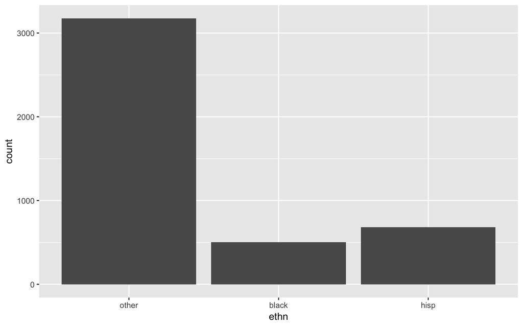

```r
ggplot(Males) +
  geom_bar(aes(ethn))
```

## Modifying Factor Order

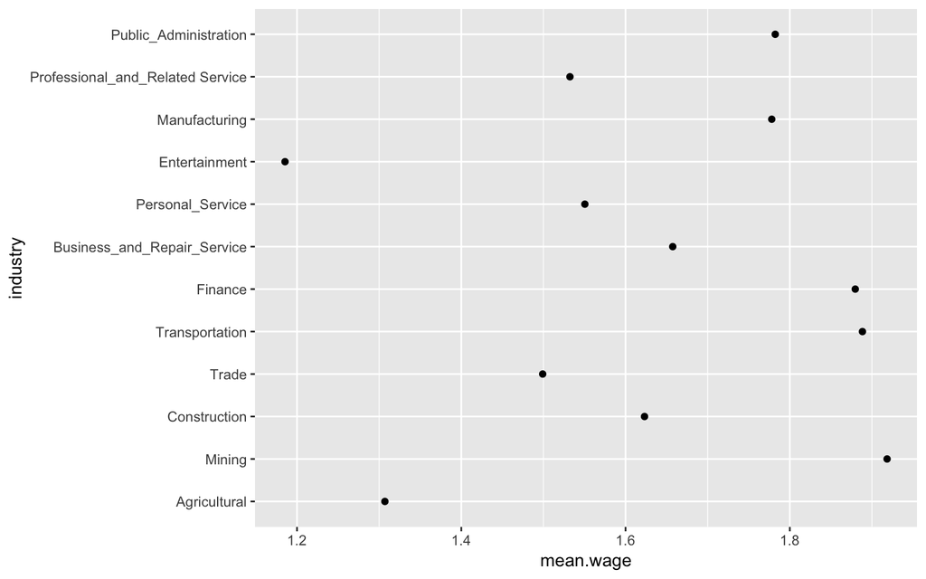

```r
Males %>%
  group_by(industry) %>%
  summarize(mean.wage = mean(wage)) %>%
ggplot() +
  geom_point(aes(mean.wage, industry))
```

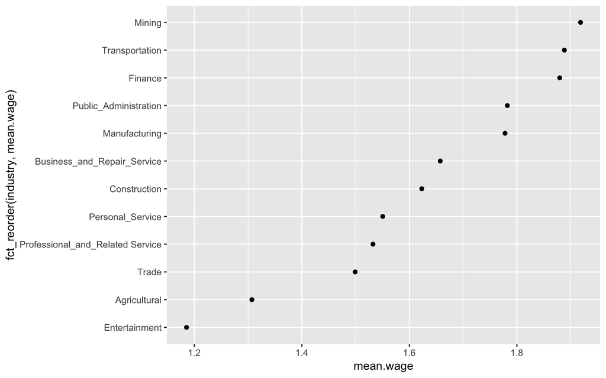

```r
Males %>%
  group_by(industry) %>%
  summarize(mean.wage = mean(wage)) %>%
ggplot() +
  geom_point(aes(mean.wage, fct_reorder(industry, mean.wage)))
```

## Modifying Factor Levels

```r
levels(Males$industry)
```

```
##  [1] "Agricultural"                     "Mining"
##  [3] "Construction"                     "Trade"
##  [5] "Transportation"                   "Finance"
##  [7] "Business_and_Repair_Service"      "Personal_Service"
##  [9] "Entertainment"                    "Manufacturing"
## [11] "Professional_and_Related Service" "Public_Administration"
```

```r
cleaned.males <- Males %>%
  mutate(industry = fct_recode(industry,
         "Professional and Related Service" = "Professional_and_Related Service",
         "Business and Repair Service" = "Business_and_Repair_Service",
         "Personal Service" = "Personal_Service",
         "Public Administration" = "Public_Administration"))
```

```r
levels(cleaned.males$industry)
```

```
##  [1] "Agricultural"                     "Mining"
##  [3] "Construction"                     "Trade"
##  [5] "Transportation"                   "Finance"
##  [7] "Business and Repair Service"      "Personal Service"
##  [9] "Entertainment"                    "Manufacturing"
## [11] "Professional and Related Service" "Public Administration"
```

`fct_recode()` will leave levels that aren’t explicitly mentioned as is, and will warn you if you accidentally refer to a level that doesn’t exist.

To combine groups, you can assign multiple old levels to the same new level

```r
cleaned.combined.males <- cleaned.males %>%
  mutate(industry = fct_recode(industry,
    "Service" = "Business and Repair Service",
    "Service" = "Professional and Related Service",
    "Service" = "Personal Service"))
levels(cleaned.combined.males$industry)
```

```
##  [1] "Agricultural"          "Mining"
##  [3] "Construction"          "Trade"
##  [5] "Transportation"        "Finance"
##  [7] "Service"               "Entertainment"
##  [9] "Manufacturing"         "Public Administration"
```

If you want to collapse a lot of levels, `fct_collapse()` is a useful variant of `fct_recode()`

```r
cleaned.concise.males <- cleaned.males %>%
  mutate(industry = fct_collapse(industry,
    Service = c("Business and Repair Service",
                "Professional and Related Service",
                "Personal Service")))
levels(cleaned.concise.males$industry)
```

```
##  [1] "Agricultural"          "Mining"
##  [3] "Construction"          "Trade"
##  [5] "Transportation"        "Finance"
##  [7] "Service"               "Entertainment"
##  [9] "Manufacturing"         "Public Administration"
```

Lutao DAI

Aug 20, 2019